# Risk Factor Analysis

## Outcome Variable

**Outcome Variable:** stunted

## Predictor Variables

**Intervention Variable:** fage

**Adjustment Set:**

- arm
- W_mage
- meducyrs
- feducyrs
- W_mhtcm
- W_mwtkg
- W_mbmi
- W_fhtcm
- single
- brthmon
- delta_W_mage
- delta_meducyrs
- delta_feducyrs
- delta_W_mhtcm
- delta_W_mwtkg
- delta_W_mbmi
- delta_W_fhtcm
- delta_single
- delta_brthmon

## Stratifying Variables

The analysis was stratified on these variable(s):

- agecat
- studyid
- country

## Data Summary

| agecat | studyid | country | fage | stunted | n_cell | n |
| --- | --- | --- | --- | --- | --- | --- |
| Birth | ki0047075b-MAL-ED | BANGLADESH | >=35 | 0 | 83 | 145 |
| Birth | ki0047075b-MAL-ED | BANGLADESH | >=35 | 1 | 16 | 145 |
| Birth | ki0047075b-MAL-ED | BANGLADESH | [25-30) | 0 | 11 | 145 |
| Birth | ki0047075b-MAL-ED | BANGLADESH | [25-30) | 1 | 2 | 145 |
| Birth | ki0047075b-MAL-ED | BANGLADESH | [30-35) | 0 | 31 | 145 |
| Birth | ki0047075b-MAL-ED | BANGLADESH | [30-35) | 1 | 2 | 145 |
| 6 months | ki0047075b-MAL-ED | BANGLADESH | >=35 | 0 | 83 | 150 |
| 6 months | ki0047075b-MAL-ED | BANGLADESH | >=35 | 1 | 18 | 150 |
| 6 months | ki0047075b-MAL-ED | BANGLADESH | [25-30) | 0 | 9 | 150 |
| 6 months | ki0047075b-MAL-ED | BANGLADESH | [25-30) | 1 | 5 | 150 |
| 6 months | ki0047075b-MAL-ED | BANGLADESH | [30-35) | 0 | 28 | 150 |
| 6 months | ki0047075b-MAL-ED | BANGLADESH | [30-35) | 1 | 7 | 150 |
| 24 months | ki0047075b-MAL-ED | BANGLADESH | >=35 | 0 | 59 | 151 |
| 24 months | ki0047075b-MAL-ED | BANGLADESH | >=35 | 1 | 43 | 151 |
| 24 months | ki0047075b-MAL-ED | BANGLADESH | [25-30) | 0 | 7 | 151 |
| 24 months | ki0047075b-MAL-ED | BANGLADESH | [25-30) | 1 | 7 | 151 |
| 24 months | ki0047075b-MAL-ED | BANGLADESH | [30-35) | 0 | 16 | 151 |
| 24 months | ki0047075b-MAL-ED | BANGLADESH | [30-35) | 1 | 19 | 151 |
| Birth | ki0047075b-MAL-ED | BRAZIL | >=35 | 0 | 31 | 68 |
| Birth | ki0047075b-MAL-ED | BRAZIL | >=35 | 1 | 4 | 68 |
| Birth | ki0047075b-MAL-ED | BRAZIL | <25 | 0 | 3 | 68 |
| Birth | ki0047075b-MAL-ED | BRAZIL | <25 | 1 | 0 | 68 |
| Birth | ki0047075b-MAL-ED | BRAZIL | [25-30) | 0 | 7 | 68 |
| Birth | ki0047075b-MAL-ED | BRAZIL | [25-30) | 1 | 0 | 68 |
| Birth | ki0047075b-MAL-ED | BRAZIL | [30-35) | 0 | 20 | 68 |
| Birth | ki0047075b-MAL-ED | BRAZIL | [30-35) | 1 | 3 | 68 |
| 6 months | ki0047075b-MAL-ED | BRAZIL | >=35 | 0 | 40 | 79 |
| 6 months | ki0047075b-MAL-ED | BRAZIL | <25 | 0 | 3 | 79 |
| 6 months | ki0047075b-MAL-ED | BRAZIL | [25-30) | 0 | 8 | 79 |
| 6 months | ki0047075b-MAL-ED | BRAZIL | [30-35) | 0 | 28 | 79 |

[output cut: 234 more lines]

The following strata were considered:

- agecat: 24 months, studyid: ki0047075b-MAL-ED, country: BANGLADESH
- agecat: 24 months, studyid: ki0047075b-MAL-ED, country: BRAZIL
- agecat: 24 months, studyid: ki0047075b-MAL-ED, country: INDIA
- agecat: 24 months, studyid: ki0047075b-MAL-ED, country: NEPAL
- agecat: 24 months, studyid: ki0047075b-MAL-ED, country: PERU
- agecat: 24 months, studyid: ki0047075b-MAL-ED, country: SOUTH AFRICA
- agecat: 24 months, studyid: ki0047075b-MAL-ED, country: TANZANIA, UNITED REPUBLIC OF
- agecat: 24 months, studyid: ki1119695-PROBIT, country: BELARUS
- agecat: 24 months, studyid: ki1135781-COHORTS, country: GUATEMALA
- agecat: 24 months, studyid: ki1135781-COHORTS, country: PHILIPPINES
- agecat: 24 months, studyid: ki1148112-LCNI-5, country: MALAWI
- agecat: 6 months, studyid: ki0047075b-MAL-ED, country: BANGLADESH
- agecat: 6 months, studyid: ki0047075b-MAL-ED, country: BRAZIL
- agecat: 6 months, studyid: ki0047075b-MAL-ED, country: INDIA
- agecat: 6 months, studyid: ki0047075b-MAL-ED, country: NEPAL
- agecat: 6 months, studyid: ki0047075b-MAL-ED, country: PERU
- agecat: 6 months, studyid: ki0047075b-MAL-ED, country: SOUTH AFRICA
- agecat: 6 months, studyid: ki0047075b-MAL-ED, country: TANZANIA, UNITED REPUBLIC OF
- agecat: 6 months, studyid: ki1000304b-SAS-CompFeed, country: INDIA
- agecat: 6 months, studyid: ki1000304b-SAS-FoodSuppl, country: INDIA
- agecat: 6 months, studyid: ki1119695-PROBIT, country: BELARUS
- agecat: 6 months, studyid: ki1135781-COHORTS, country: GUATEMALA
- agecat: 6 months, studyid: ki1135781-COHORTS, country: PHILIPPINES
- agecat: 6 months, studyid: ki1148112-LCNI-5, country: MALAWI
- agecat: Birth, studyid: ki0047075b-MAL-ED, country: BANGLADESH
- agecat: Birth, studyid: ki0047075b-MAL-ED, country: BRAZIL
- agecat: Birth, studyid: ki0047075b-MAL-ED, country: INDIA
- agecat: Birth, studyid: ki0047075b-MAL-ED, country: NEPAL
- agecat: Birth, studyid: ki0047075b-MAL-ED, country: PERU
- agecat: Birth, studyid: ki0047075b-MAL-ED, country: SOUTH AFRICA
- agecat: Birth, studyid: ki0047075b-MAL-ED, country: TANZANIA, UNITED REPUBLIC OF
- agecat: Birth, studyid: ki1000304b-SAS-CompFeed, country: INDIA
- agecat: Birth, studyid: ki1119695-PROBIT, country: BELARUS
- agecat: Birth, studyid: ki1135781-COHORTS, country: GUATEMALA
- agecat: Birth, studyid: ki1135781-COHORTS, country: PHILIPPINES

### Dropped Strata

Some strata were dropped due to rare outcomes:

- agecat: Birth, studyid: ki0047075b-MAL-ED, country: BANGLADESH
- agecat: Birth, studyid: ki0047075b-MAL-ED, country: BRAZIL
- agecat: 6 months, studyid: ki0047075b-MAL-ED, country: BRAZIL
- agecat: 24 months, studyid: ki0047075b-MAL-ED, country: BRAZIL
- agecat: Birth, studyid: ki0047075b-MAL-ED, country: INDIA
- agecat: 6 months, studyid: ki0047075b-MAL-ED, country: INDIA
- agecat: 24 months, studyid: ki0047075b-MAL-ED, country: INDIA
- agecat: Birth, studyid: ki0047075b-MAL-ED, country: NEPAL
- agecat: 6 months, studyid: ki0047075b-MAL-ED, country: NEPAL
- agecat: 24 months, studyid: ki0047075b-MAL-ED, country: NEPAL
- agecat: Birth, studyid: ki0047075b-MAL-ED, country: PERU
- agecat: 6 months, studyid: ki0047075b-MAL-ED, country: PERU
- agecat: 24 months, studyid: ki0047075b-MAL-ED, country: PERU
- agecat: Birth, studyid: ki0047075b-MAL-ED, country: SOUTH AFRICA
- agecat: 6 months, studyid: ki0047075b-MAL-ED, country: SOUTH AFRICA
- agecat: 24 months, studyid: ki0047075b-MAL-ED, country: SOUTH AFRICA
- agecat: Birth, studyid: ki0047075b-MAL-ED, country: TANZANIA, UNITED REPUBLIC OF
- agecat: 6 months, studyid: ki0047075b-MAL-ED, country: TANZANIA, UNITED REPUBLIC OF
- agecat: 24 months, studyid: ki0047075b-MAL-ED, country: TANZANIA, UNITED REPUBLIC OF
- agecat: Birth, studyid: ki1000304b-SAS-CompFeed, country: INDIA
- agecat: Birth, studyid: ki1119695-PROBIT, country: BELARUS
- agecat: 24 months, studyid: ki1148112-LCNI-5, country: MALAWI

## Methods Detail

We’re interested in the causal parameters $E[Y_a]$ for all values of $a \in \mathcal{A}$. These parameters represent the mean outcome if, possibly contrary to fact, we intervened to set all units to have $A=a$. Under the randomization and positivity assumptions, these are identified by the statistical parameters $\psi_a=E_W[E_{Y|A,W}(Y|A=a,W)]$. In addition, we’re interested in the mean of $Y$, $E[Y]$ under no intervention (the observed mean). We will estimate these parameters by using SuperLearner to fit the relevant likelihood factors – $E_{Y|A,W}(Y|A=a,W)$ and $p(A=a|W)$, and then updating our likelihood fit using a joint TMLE.

For unadjusted analyses ($W=\{\}$), initial likelihoods were estimated using Lrnr_glm to estimate the simple $E(Y|A)$ and Lrnr_mean to estimate $p(A)$. For adjusted analyses, a small library containing Lrnr_glmnet, Lrnr_xgboost, and Lrnr_mean was used.

Having estimated these parameters, we will then use the delta method to estimate relative risks and attributable risks relative to a prespecified baseline level of $A$.

[output not shown]

[output not shown]

# Results Detail

## Results Plots

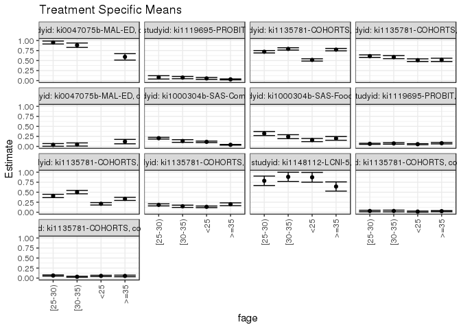

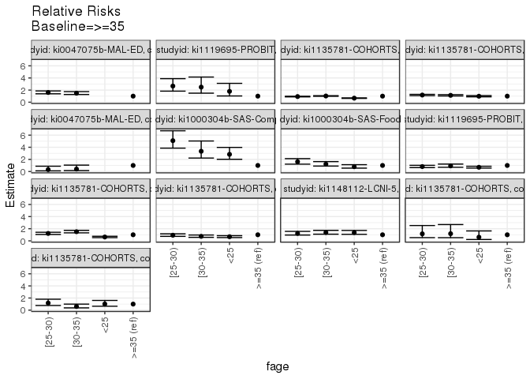

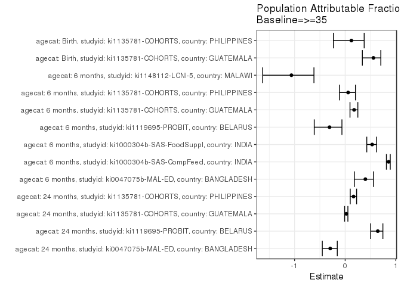

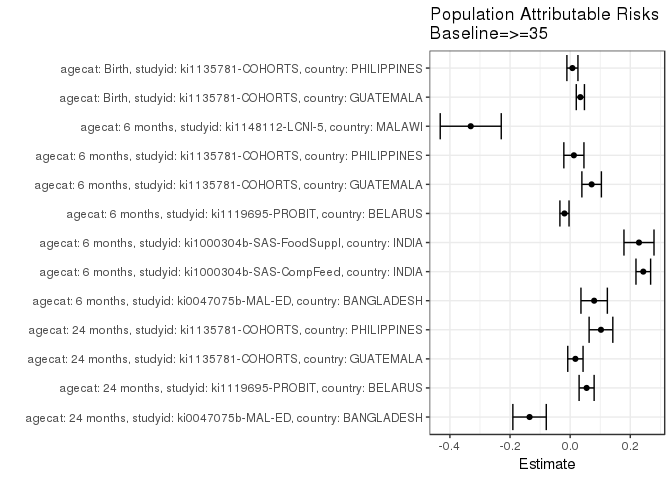

## Results Table

### Parameter: TSM

| agecat | studyid | country | intervention_level | baseline_level | estimate | ci_lower | ci_upper |
| --- | --- | --- | --- | --- | --- | --- | --- |
| Birth | ki1135781-COHORTS | GUATEMALA | >=35 | NA | 0.0268528 | 0.0134190 | 0.0402865 |
| Birth | ki1135781-COHORTS | GUATEMALA | <25 | NA | 0.0161798 | 0.0022479 | 0.0301117 |
| Birth | ki1135781-COHORTS | GUATEMALA | [25-30) | NA | 0.0309924 | 0.0123457 | 0.0496391 |
| Birth | ki1135781-COHORTS | GUATEMALA | [30-35) | NA | 0.0316465 | 0.0107945 | 0.0524986 |
| Birth | ki1135781-COHORTS | PHILIPPINES | >=35 | NA | 0.0536376 | 0.0346088 | 0.0726664 |
| Birth | ki1135781-COHORTS | PHILIPPINES | <25 | NA | 0.0545772 | 0.0389599 | 0.0701945 |
| Birth | ki1135781-COHORTS | PHILIPPINES | [25-30) | NA | 0.0629811 | 0.0479197 | 0.0780425 |
| Birth | ki1135781-COHORTS | PHILIPPINES | [30-35) | NA | 0.0327464 | 0.0216375 | 0.0438554 |
| 6 months | ki0047075b-MAL-ED | BANGLADESH | >=35 | NA | 0.1201693 | 0.0651089 | 0.1752298 |
| 6 months | ki0047075b-MAL-ED | BANGLADESH | [25-30) | NA | 0.0378536 | 0.0043038 | 0.0714035 |
| 6 months | ki0047075b-MAL-ED | BANGLADESH | [30-35) | NA | 0.0479226 | 0.0082759 | 0.0875693 |
| 6 months | ki1000304b-SAS-CompFeed | INDIA | >=35 | NA | 0.0402856 | 0.0312907 | 0.0492806 |
| 6 months | ki1000304b-SAS-CompFeed | INDIA | <25 | NA | 0.1140856 | 0.0947805 | 0.1333908 |
| 6 months | ki1000304b-SAS-CompFeed | INDIA | [25-30) | NA | 0.2050593 | 0.1837643 | 0.2263543 |
| 6 months | ki1000304b-SAS-CompFeed | INDIA | [30-35) | NA | 0.1346583 | 0.1011148 | 0.1682018 |
| 6 months | ki1000304b-SAS-FoodSuppl | INDIA | >=35 | NA | 0.2000110 | 0.1535426 | 0.2464795 |
| 6 months | ki1000304b-SAS-FoodSuppl | INDIA | <25 | NA | 0.1588298 | 0.1192907 | 0.1983689 |
| 6 months | ki1000304b-SAS-FoodSuppl | INDIA | [25-30) | NA | 0.3213845 | 0.2708509 | 0.3719180 |
| 6 months | ki1000304b-SAS-FoodSuppl | INDIA | [30-35) | NA | 0.2430640 | 0.1933184 | 0.2928096 |
| 6 months | ki1119695-PROBIT | BELARUS | >=35 | NA | 0.0801211 | 0.0622450 | 0.0979972 |
| 6 months | ki1119695-PROBIT | BELARUS | <25 | NA | 0.0559663 | 0.0428197 | 0.0691128 |
| 6 months | ki1119695-PROBIT | BELARUS | [25-30) | NA | 0.0650458 | 0.0516577 | 0.0784339 |
| 6 months | ki1119695-PROBIT | BELARUS | [30-35) | NA | 0.0742879 | 0.0558016 | 0.0927741 |
| 6 months | ki1135781-COHORTS | GUATEMALA | >=35 | NA | 0.3333070 | 0.2948054 | 0.3718086 |
| 6 months | ki1135781-COHORTS | GUATEMALA | <25 | NA | 0.2107944 | 0.1808273 | 0.2407616 |
| 6 months | ki1135781-COHORTS | GUATEMALA | [25-30) | NA | 0.4065550 | 0.3653187 | 0.4477913 |
| 6 months | ki1135781-COHORTS | GUATEMALA | [30-35) | NA | 0.5028892 | 0.4602613 | 0.5455170 |
| 6 months | ki1135781-COHORTS | PHILIPPINES | >=35 | NA | 0.1994860 | 0.1646786 | 0.2342933 |
| 6 months | ki1135781-COHORTS | PHILIPPINES | <25 | NA | 0.1351415 | 0.1147456 | 0.1555373 |
| 6 months | ki1135781-COHORTS | PHILIPPINES | [25-30) | NA | 0.1844462 | 0.1584087 | 0.2104838 |
| 6 months | ki1135781-COHORTS | PHILIPPINES | [30-35) | NA | 0.1482446 | 0.1201507 | 0.1763385 |
| 6 months | ki1148112-LCNI-5 | MALAWI | >=35 | NA | 0.6420619 | 0.5270047 | 0.7571191 |
| 6 months | ki1148112-LCNI-5 | MALAWI | <25 | NA | 0.8728649 | 0.7514319 | 0.9942979 |
| 6 months | ki1148112-LCNI-5 | MALAWI | [25-30) | NA | 0.7847369 | 0.6671229 | 0.9023508 |
| 6 months | ki1148112-LCNI-5 | MALAWI | [30-35) | NA | 0.8837389 | 0.7688720 | 0.9986059 |
| 24 months | ki0047075b-MAL-ED | BANGLADESH | >=35 | NA | 0.5920004 | 0.5121481 | 0.6718528 |
| 24 months | ki0047075b-MAL-ED | BANGLADESH | [25-30) | NA | 0.9507531 | 0.9141325 | 0.9873736 |
| 24 months | ki0047075b-MAL-ED | BANGLADESH | [30-35) | NA | 0.8830548 | 0.8279586 | 0.9381511 |
| 24 months | ki1119695-PROBIT | BELARUS | >=35 | NA | 0.0301915 | 0.0187126 | 0.0416703 |
| 24 months | ki1119695-PROBIT | BELARUS | <25 | NA | 0.0540325 | 0.0312081 | 0.0768569 |
| 24 months | ki1119695-PROBIT | BELARUS | [25-30) | NA | 0.0804289 | 0.0390408 | 0.1218170 |
| 24 months | ki1119695-PROBIT | BELARUS | [30-35) | NA | 0.0750987 | 0.0468469 | 0.1033506 |
| 24 months | ki1135781-COHORTS | GUATEMALA | >=35 | NA | 0.7726025 | 0.7425256 | 0.8026793 |
| 24 months | ki1135781-COHORTS | GUATEMALA | <25 | NA | 0.5156299 | 0.4870455 | 0.5442143 |
| 24 months | ki1135781-COHORTS | GUATEMALA | [25-30) | NA | 0.7199404 | 0.6895389 | 0.7503420 |
| 24 months | ki1135781-COHORTS | GUATEMALA | [30-35) | NA | 0.7907409 | 0.7616775 | 0.8198043 |
| 24 months | ki1135781-COHORTS | PHILIPPINES | >=35 | NA | 0.5171014 | 0.4763139 | 0.5578888 |
| 24 months | ki1135781-COHORTS | PHILIPPINES | <25 | NA | 0.5096485 | 0.4762710 | 0.5430261 |
| 24 months | ki1135781-COHORTS | PHILIPPINES | [25-30) | NA | 0.6105168 | 0.5787997 | 0.6422339 |
| 24 months | ki1135781-COHORTS | PHILIPPINES | [30-35) | NA | 0.5856292 | 0.5477779 | 0.6234805 |

### Parameter: E(Y)

| agecat | studyid | country | intervention_level | baseline_level | estimate | ci_lower | ci_upper |
| --- | --- | --- | --- | --- | --- | --- | --- |
| Birth | ki1135781-COHORTS | GUATEMALA | NA | NA | 0.0607533 | 0.0444233 | 0.0770834 |
| Birth | ki1135781-COHORTS | PHILIPPINES | NA | NA | 0.0611413 | 0.0524852 | 0.0697974 |
| 6 months | ki0047075b-MAL-ED | BANGLADESH | NA | NA | 0.2000000 | 0.1357734 | 0.2642266 |
| 6 months | ki1000304b-SAS-CompFeed | INDIA | NA | NA | 0.2835709 | 0.2656121 | 0.3015297 |
| 6 months | ki1000304b-SAS-FoodSuppl | INDIA | NA | NA | 0.4289474 | 0.3791199 | 0.4787748 |
| 6 months | ki1119695-PROBIT | BELARUS | NA | NA | 0.0611869 | 0.0477477 | 0.0746260 |
| 6 months | ki1135781-COHORTS | GUATEMALA | NA | NA | 0.4047363 | 0.3731561 | 0.4363165 |
| 6 months | ki1135781-COHORTS | PHILIPPINES | NA | NA | 0.2118902 | 0.1962516 | 0.2275288 |
| 6 months | ki1148112-LCNI-5 | MALAWI | NA | NA | 0.3113208 | 0.2227550 | 0.3998865 |
| 24 months | ki0047075b-MAL-ED | BANGLADESH | NA | NA | 0.4569536 | 0.3772355 | 0.5366718 |
| 24 months | ki1119695-PROBIT | BELARUS | NA | NA | 0.0849322 | 0.0549995 | 0.1148649 |
| 24 months | ki1135781-COHORTS | GUATEMALA | NA | NA | 0.7900391 | 0.7650814 | 0.8149967 |
| 24 months | ki1135781-COHORTS | PHILIPPINES | NA | NA | 0.6195698 | 0.6000239 | 0.6391157 |

### Parameter: RR

| agecat | studyid | country | intervention_level | baseline_level | estimate | ci_lower | ci_upper |
| --- | --- | --- | --- | --- | --- | --- | --- |
| Birth | ki1135781-COHORTS | GUATEMALA | >=35 | >=35 | 1.0000000 | 1.0000000 | 1.0000000 |
| Birth | ki1135781-COHORTS | GUATEMALA | <25 | >=35 | 0.6025371 | 0.2219967 | 1.6353885 |
| Birth | ki1135781-COHORTS | GUATEMALA | [25-30) | >=35 | 1.1541602 | 0.5270725 | 2.5273292 |
| Birth | ki1135781-COHORTS | GUATEMALA | [30-35) | >=35 | 1.1785207 | 0.5170703 | 2.6861163 |
| Birth | ki1135781-COHORTS | PHILIPPINES | >=35 | >=35 | 1.0000000 | 1.0000000 | 1.0000000 |
| Birth | ki1135781-COHORTS | PHILIPPINES | <25 | >=35 | 1.0175175 | 0.6452000 | 1.6046837 |
| Birth | ki1135781-COHORTS | PHILIPPINES | [25-30) | >=35 | 1.1741967 | 0.7662743 | 1.7992745 |
| Birth | ki1135781-COHORTS | PHILIPPINES | [30-35) | >=35 | 0.6105129 | 0.3740512 | 0.9964573 |
| 6 months | ki0047075b-MAL-ED | BANGLADESH | >=35 | >=35 | 1.0000000 | 1.0000000 | 1.0000000 |
| 6 months | ki0047075b-MAL-ED | BANGLADESH | [25-30) | >=35 | 0.3150025 | 0.1131819 | 0.8766997 |
| 6 months | ki0047075b-MAL-ED | BANGLADESH | [30-35) | >=35 | 0.3987923 | 0.1507900 | 1.0546807 |
| 6 months | ki1000304b-SAS-CompFeed | INDIA | >=35 | >=35 | 1.0000000 | 1.0000000 | 1.0000000 |
| 6 months | ki1000304b-SAS-CompFeed | INDIA | <25 | >=35 | 2.8319190 | 2.0175245 | 3.9750521 |
| 6 months | ki1000304b-SAS-CompFeed | INDIA | [25-30) | >=35 | 5.0901345 | 3.8547618 | 6.7214189 |
| 6 months | ki1000304b-SAS-CompFeed | INDIA | [30-35) | >=35 | 3.3425890 | 2.2195122 | 5.0339444 |
| 6 months | ki1000304b-SAS-FoodSuppl | INDIA | >=35 | >=35 | 1.0000000 | 1.0000000 | 1.0000000 |
| 6 months | ki1000304b-SAS-FoodSuppl | INDIA | <25 | >=35 | 0.7941053 | 0.5579928 | 1.1301278 |
| 6 months | ki1000304b-SAS-FoodSuppl | INDIA | [25-30) | >=35 | 1.6068337 | 1.2164718 | 2.1224616 |
| 6 months | ki1000304b-SAS-FoodSuppl | INDIA | [30-35) | >=35 | 1.2152529 | 0.9021530 | 1.6370168 |
| 6 months | ki1119695-PROBIT | BELARUS | >=35 | >=35 | 1.0000000 | 1.0000000 | 1.0000000 |
| 6 months | ki1119695-PROBIT | BELARUS | <25 | >=35 | 0.6985206 | 0.5632590 | 0.8662641 |
| 6 months | ki1119695-PROBIT | BELARUS | [25-30) | >=35 | 0.8118428 | 0.6444280 | 1.0227500 |
| 6 months | ki1119695-PROBIT | BELARUS | [30-35) | >=35 | 0.9271946 | 0.7000688 | 1.2280076 |
| 6 months | ki1135781-COHORTS | GUATEMALA | >=35 | >=35 | 1.0000000 | 1.0000000 | 1.0000000 |
| 6 months | ki1135781-COHORTS | GUATEMALA | <25 | >=35 | 0.6324333 | 0.5292179 | 0.7557792 |
| 6 months | ki1135781-COHORTS | GUATEMALA | [25-30) | >=35 | 1.2197614 | 1.0521026 | 1.4141375 |
| 6 months | ki1135781-COHORTS | GUATEMALA | [30-35) | >=35 | 1.5087868 | 1.3148634 | 1.7313110 |
| 6 months | ki1135781-COHORTS | PHILIPPINES | >=35 | >=35 | 1.0000000 | 1.0000000 | 1.0000000 |
| 6 months | ki1135781-COHORTS | PHILIPPINES | <25 | >=35 | 0.6774484 | 0.5379529 | 0.8531163 |
| 6 months | ki1135781-COHORTS | PHILIPPINES | [25-30) | >=35 | 0.9246075 | 0.7394125 | 1.1561868 |
| 6 months | ki1135781-COHORTS | PHILIPPINES | [30-35) | >=35 | 0.7431329 | 0.5749496 | 0.9605128 |
| 6 months | ki1148112-LCNI-5 | MALAWI | >=35 | >=35 | 1.0000000 | 1.0000000 | 1.0000000 |
| 6 months | ki1148112-LCNI-5 | MALAWI | <25 | >=35 | 1.3594716 | 1.0765492 | 1.7167473 |
| 6 months | ki1148112-LCNI-5 | MALAWI | [25-30) | >=35 | 1.2222137 | 0.9575964 | 1.5599540 |
| 6 months | ki1148112-LCNI-5 | MALAWI | [30-35) | >=35 | 1.3764077 | 1.0953746 | 1.7295436 |
| 24 months | ki0047075b-MAL-ED | BANGLADESH | >=35 | >=35 | 1.0000000 | 1.0000000 | 1.0000000 |
| 24 months | ki0047075b-MAL-ED | BANGLADESH | [25-30) | >=35 | 1.6060006 | 1.3869414 | 1.8596589 |
| 24 months | ki0047075b-MAL-ED | BANGLADESH | [30-35) | >=35 | 1.4916456 | 1.2739117 | 1.7465939 |
| 24 months | ki1119695-PROBIT | BELARUS | >=35 | >=35 | 1.0000000 | 1.0000000 | 1.0000000 |
| 24 months | ki1119695-PROBIT | BELARUS | <25 | >=35 | 1.7896598 | 1.0305865 | 3.1078245 |
| 24 months | ki1119695-PROBIT | BELARUS | [25-30) | >=35 | 2.6639617 | 1.8254357 | 3.8876702 |
| 24 months | ki1119695-PROBIT | BELARUS | [30-35) | >=35 | 2.4874144 | 1.4896388 | 4.1535104 |
| 24 months | ki1135781-COHORTS | GUATEMALA | >=35 | >=35 | 1.0000000 | 1.0000000 | 1.0000000 |
| 24 months | ki1135781-COHORTS | GUATEMALA | <25 | >=35 | 0.6673935 | 0.6259899 | 0.7115357 |
| 24 months | ki1135781-COHORTS | GUATEMALA | [25-30) | >=35 | 0.9318381 | 0.8825945 | 0.9838292 |
| 24 months | ki1135781-COHORTS | GUATEMALA | [30-35) | >=35 | 1.0234771 | 0.9727128 | 1.0768907 |
| 24 months | ki1135781-COHORTS | PHILIPPINES | >=35 | >=35 | 1.0000000 | 1.0000000 | 1.0000000 |
| 24 months | ki1135781-COHORTS | PHILIPPINES | <25 | >=35 | 0.9855872 | 0.8899500 | 1.0915020 |
| 24 months | ki1135781-COHORTS | PHILIPPINES | [25-30) | >=35 | 1.1806520 | 1.0754758 | 1.2961138 |
| 24 months | ki1135781-COHORTS | PHILIPPINES | [30-35) | >=35 | 1.1325230 | 1.0241448 | 1.2523700 |

### Parameter: PAR

| agecat | studyid | country | intervention_level | baseline_level | estimate | ci_lower | ci_upper |
| --- | --- | --- | --- | --- | --- | --- | --- |
| Birth | ki1135781-COHORTS | GUATEMALA | >=35 | NA | 0.0339006 | 0.0203302 | 0.0474710 |
| Birth | ki1135781-COHORTS | PHILIPPINES | >=35 | NA | 0.0075037 | -0.0108759 | 0.0258833 |
| 6 months | ki0047075b-MAL-ED | BANGLADESH | >=35 | NA | 0.0798307 | 0.0359180 | 0.1237434 |
| 6 months | ki1000304b-SAS-CompFeed | INDIA | >=35 | NA | 0.2432853 | 0.2189176 | 0.2676529 |
| 6 months | ki1000304b-SAS-FoodSuppl | INDIA | >=35 | NA | 0.2289363 | 0.1789635 | 0.2789092 |
| 6 months | ki1119695-PROBIT | BELARUS | >=35 | NA | -0.0189343 | -0.0341191 | -0.0037494 |
| 6 months | ki1135781-COHORTS | GUATEMALA | >=35 | NA | 0.0714293 | 0.0389814 | 0.1038771 |
| 6 months | ki1135781-COHORTS | PHILIPPINES | >=35 | NA | 0.0124043 | -0.0210290 | 0.0458375 |
| 6 months | ki1148112-LCNI-5 | MALAWI | >=35 | NA | -0.3307412 | -0.4322452 | -0.2292371 |
| 24 months | ki0047075b-MAL-ED | BANGLADESH | >=35 | NA | -0.1350468 | -0.1906117 | -0.0794819 |
| 24 months | ki1119695-PROBIT | BELARUS | >=35 | NA | 0.0547407 | 0.0297492 | 0.0797322 |
| 24 months | ki1135781-COHORTS | GUATEMALA | >=35 | NA | 0.0174366 | -0.0080142 | 0.0428874 |
| 24 months | ki1135781-COHORTS | PHILIPPINES | >=35 | NA | 0.1024684 | 0.0630421 | 0.1418947 |

### Parameter: PAF

| agecat | studyid | country | intervention_level | baseline_level | estimate | ci_lower | ci_upper |
| --- | --- | --- | --- | --- | --- | --- | --- |
| Birth | ki1135781-COHORTS | GUATEMALA | >=35 | NA | 0.5580034 | 0.3395282 | 0.7042099 |
| Birth | ki1135781-COHORTS | PHILIPPINES | >=35 | NA | 0.1227275 | -0.2326116 | 0.3756289 |
| 6 months | ki0047075b-MAL-ED | BANGLADESH | >=35 | NA | 0.3991533 | 0.1815544 | 0.5588995 |
| 6 months | ki1000304b-SAS-CompFeed | INDIA | >=35 | NA | 0.8579345 | 0.8147220 | 0.8910686 |
| 6 months | ki1000304b-SAS-FoodSuppl | INDIA | >=35 | NA | 0.5337166 | 0.4270039 | 0.6205556 |
| 6 months | ki1119695-PROBIT | BELARUS | >=35 | NA | -0.3094501 | -0.6113078 | -0.0641415 |
| 6 months | ki1135781-COHORTS | GUATEMALA | >=35 | NA | 0.1764835 | 0.0952272 | 0.2504423 |
| 6 months | ki1135781-COHORTS | PHILIPPINES | >=35 | NA | 0.0585410 | -0.1125700 | 0.2033354 |
| 6 months | ki1148112-LCNI-5 | MALAWI | >=35 | NA | -1.0623807 | -1.6300520 | -0.6172357 |
| 24 months | ki0047075b-MAL-ED | BANGLADESH | >=35 | NA | -0.2955372 | -0.4518670 | -0.1560402 |
| 24 months | ki1119695-PROBIT | BELARUS | >=35 | NA | 0.6445226 | 0.5035741 | 0.7454521 |
| 24 months | ki1135781-COHORTS | GUATEMALA | >=35 | NA | 0.0220705 | -0.0104802 | 0.0535727 |
| 24 months | ki1135781-COHORTS | PHILIPPINES | >=35 | NA | 0.1653864 | 0.1000327 | 0.2259943 |